# Modeling How Well Users Perform the Bicep Curl Exercise

TI

2022-06-10

# Introduction

This report will attempt to model, and predict, how well a person will perform a bicep curl. The data set used is provided by http://groupware.les.inf.puc-rio.br/har, and contains accelerometer data from the belt, forearm, arm, and dumbbell of 6 study participants. The participants were asked to perform barbell lifts correctly and incorrectly in 5 different ways. This report will explore the data, select covariates to use within a model, and train multiple models to find the best model fit.

Class A = Exactly according to specifications Class B = Throwing the elbows to the front Class C = Lifting the dumbbell only halfway Class D = Lowering the dumbbell only halfway Class E = Throwing the hips to the front

```r
library(dplyr)
library(readr)
library(caret)
library(ggplot2)
library(ggcorrplot)
library(car)
library(Hmisc)

set.seed(1234)
```

# The Data

The data set is provided by: http://groupware.les.inf.puc-rio.br/har and is provided pre-split to a training and testing set. The testing set is not downloaded or used as it will only be used as part of the Coursera course’s quiz.

```r
link_to_training <- "https://d396qusza40orc.cloudfront.net/predmachlearn/pml-training.csv"
training <- read_csv(link_to_training)
```

The data sets contains 19,622 observations with 160 variables. The *classe* variable will be the prediction variable. There are 5 different classes, and therefore a multiclass classification model will need to be created. The classes are as follows:

- Class A = Exactly according to specifications
- Class B = Throwing the elbows to the front
- Class C = Lifting the dumbbell only halfway
- Class D = Lowering the dumbbell only halfway
- Class E = Throwing the hips to the front

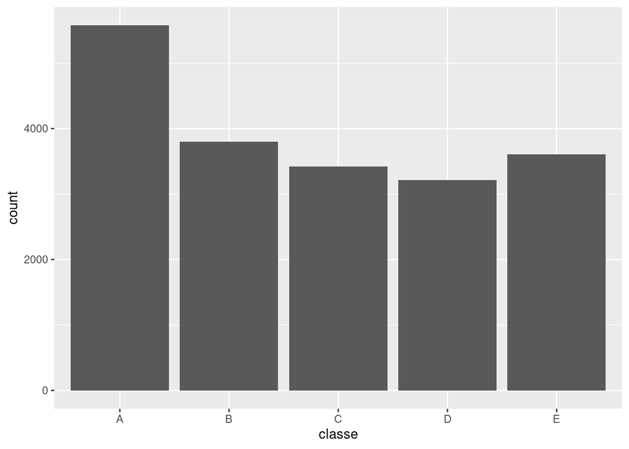

```r
ggplot(data = training, aes(x = classe)) + geom_histogram(stat="count")
```

## Covariate Selection

### Level One

One hundred of the variables have significant amounts of missing data (97% or greater of the rows having missing data). These columns will not be used. The remaining columns have no missing data and will be carried forward.

There are seven variables that will be removed the training data set as they are not significant to a person performing an exercise. Further reasoning is provided in the following table.

Table 1. Covariate’s that are not significant to a person performing the dumbbell exercise

| Covariate | Reasoning |
| --- | --- |
| …1 | This was the index of the data set |
| user_name | In order to generalize the model better, the specific person performing the exercise should not be in the model |
| raw_timestamp_part_1 | The data is not bound by time |
| raw_timestamp_part_2 | The data is not bound by time |
| cvtd_timestamp | The data is not bound by time |
| new_window | I was not able to find information on what this represents, and will be removed from the model for this reason |
| num_window | I was not able to find information on what this represents, and will be removed from the model for this reason |

```r
columns_with_na_count <- sapply(training, function(x) sum(is.na(x)))
columns_with_no_missing_data <- names(columns_with_na_count[columns_with_na_count == 0])
columns_not_significant <- c(
    "...1", "user_name", "raw_timestamp_part_1",
    "raw_timestamp_part_2", "cvtd_timestamp", "new_window", "num_window"
)

trainingTidy <- training %>%
    select(any_of(columns_with_no_missing_data)) %>%
    select(!all_of(columns_not_significant)) %>%
    transform(classe = factor(classe))

in_training <- createDataPartition(trainingTidy$classe, p=0.6, list = F)
training_split <- trainingTidy[in_training,]
validation <- trainingTidy[-in_training,]

training_y <- training_split$classe
training_X <- training_split %>% select(!matches("classe"))
```

### Level Two

The next step in the covariate selection will be to standardize. This will improve the model performance. An the non-standardized data is shown below to illustrate the range of values present in the dataset.

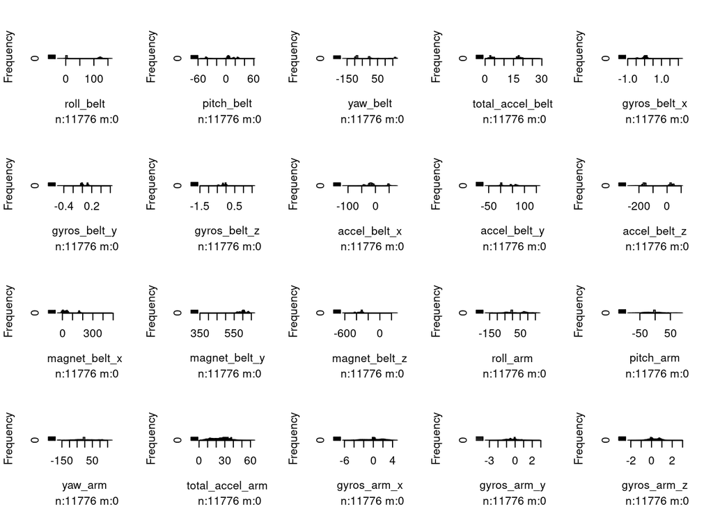

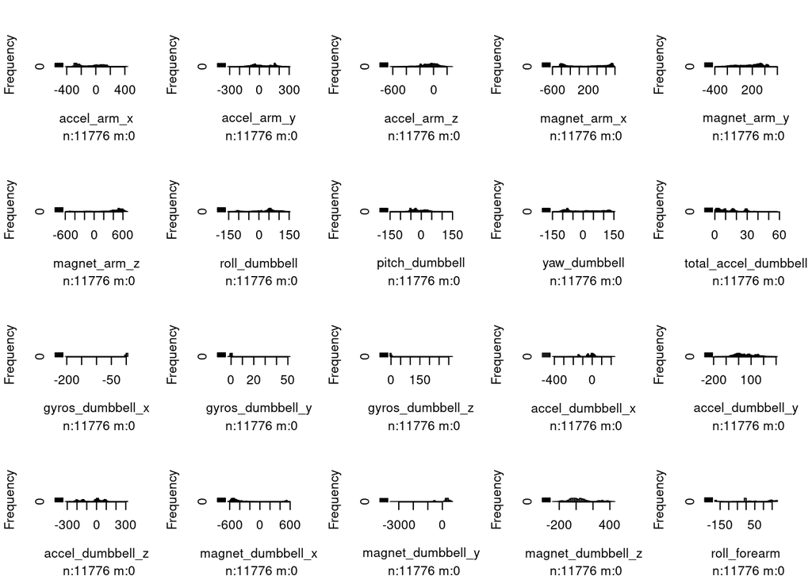

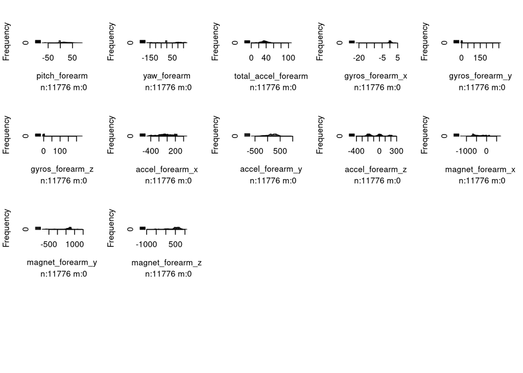

```r
hist.data.frame(training_X)
```

```r
# Center and Scaled
standardized_X <- preProcess(training_X)
training_X_sc <- predict(standardized_X, newdata = training_X)
```

We will now look at correlations within the data set to see if any covariates are strongly correlated. If they are, Principle Component Analysis will be used to de-correlate and reduce the data sets dimensions.

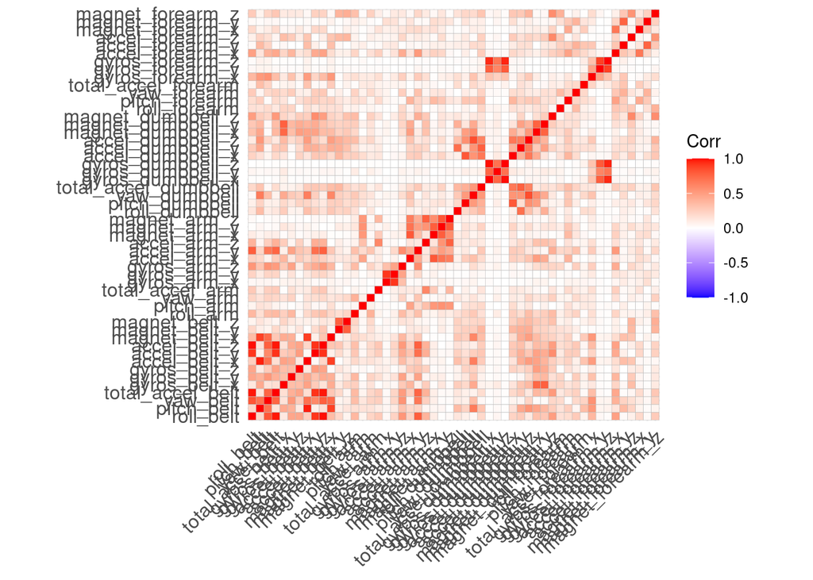

```r
corr <- abs(cor(training_X_sc))
ggcorrplot(corr)
```

As shown in the figure, there are quite a few highly correlated covariates. This is concerning as the model may not fit well to out of sample data if these correlations remain.

The following code will remove the correlations using Principle Component Analysis (PCA). The default settings will be used with `prcomp` as it will select the optimal number of components based on the input. Only variables with a correlation of greater then or equal to 0.8 will be included in the PCA.

```r
diag(corr) <- 0
highly_corr_columns <- rownames(which(corr >= 0.8, arr.ind = T))
highly_corr_data <- training_X_sc %>% select(all_of(highly_corr_columns))

pca_processed_X <- prcomp(highly_corr_data)
training_X_pca <- training_X_sc %>%
    select(!matches(highly_corr_columns)) %>%
    mutate(pca = pca_processed_X$x)

training_X_fin <- training_X_pca
```

## Transformation Pipeline

The following is a transformation pipeline to be used with the test set. It includes all the transformations used above.

```r
transform.pipeline <- function(x) {
    columns_with_no_missing_data <- append(columns_with_no_missing_data, "problem_id")
    x_out <- x %>%
        select(any_of(columns_with_no_missing_data)) %>%
        select(!any_of(columns_not_significant)) %>%
        select(!matches("classe")) %>%
        select(!matches("problem_id"))  ## This variable is in the test set, needs to be removed while performing the test

    x_out <- predict(standardized_X, newdata = x_out)

    x_pca_in <- x_out %>% select(all_of(highly_corr_columns))
    x_pca_out <- predict(pca_processed_X, x_pca_in)

    x_out <- x_out %>%
        select(!matches(highly_corr_columns)) %>%
        mutate(pca = x_pca_out)

    x_out
}
```

# Model Selection

Three models will be trained in attempt to find the best fitting model. The models will then be used to predict against the validation data set to see how well they will perform on out of sample data. The library `doParallel` will be loaded to utilized multiple cores on the computer to improve training speeds.

### Cross Validation

Cross validation will be utilized to further tune the model training. The same controls will be used on all model training. As well another `dataframe` of the transformed data is created with `cbind` so it can be used within the training function.

```r
library(doParallel)
fit_control <- trainControl(
    method="cv",
    classProbs = TRUE,
    summaryFunction = multiClassSummary
)
training_in <- cbind(classe = training_y, training_X_fin)
valid_transform <- transform.pipeline(validation)
```

## K-Nearest Neighbor

```r
cl <- makePSOCKcluster(6)
registerDoParallel(cl)

mdl_knn <- train(
    classe ~ .,
    method = "knn",
    data=training_in,
    trControl = fit_control
)

stopCluster(cl)
mdl_knn
```

```
## k-Nearest Neighbors
##
## 11776 samples
##    31 predictor
##     5 classes: 'A', 'B', 'C', 'D', 'E'
##
## No pre-processing
## Resampling: Cross-Validated (10 fold)
## Summary of sample sizes: 10597, 10599, 10597, 10599, 10600, 10597, ...
## Resampling results across tuning parameters:
##
##   k  logLoss    AUC        prAUC      Accuracy   Kappa      Mean_F1
##   5  0.2573130  0.9950692  0.1877654  0.9501532  0.9369271  0.9473310
##   7  0.2473149  0.9945824  0.2698103  0.9346096  0.9172424  0.9314275
##   9  0.2502193  0.9936762  0.3356104  0.9228931  0.9023959  0.9190462
##   Mean_Sensitivity  Mean_Specificity  Mean_Pos_Pred_Value  Mean_Neg_Pred_Value
##   0.9466762         0.9875261         0.9487587            0.9876690
##   0.9304175         0.9835826         0.9336030            0.9838030
##   0.9177822         0.9806454         0.9219192            0.9809294
##   Mean_Precision  Mean_Recall  Mean_Detection_Rate  Mean_Balanced_Accuracy
##   0.9487587       0.9466762    0.1900306            0.9671012
##   0.9336030       0.9304175    0.1869219            0.9570001
##   0.9219192       0.9177822    0.1845786            0.9492138
##
## Accuracy was used to select the optimal model using the largest value.
## The final value used for the model was k = 5.
```

### Validation

```r
predict_knn <- predict(mdl_knn, valid_transform)
confusionMatrix(predict_knn, validation$classe)
```

```
## Confusion Matrix and Statistics
##
##           Reference
## Prediction    A    B    C    D    E
##          A 2197   43    8    6    4
##          B   19 1422   26    1   18
##          C    6   34 1295   52   21
##          D    7   10   34 1222    8
##          E    3    9    5    5 1391
##
## Overall Statistics
##
##                Accuracy : 0.9593
##                  95% CI : (0.9547, 0.9636)
##     No Information Rate : 0.2845
##     P-Value [Acc > NIR] : < 2.2e-16
##
##                   Kappa : 0.9486
##
##  Mcnemar's Test P-Value : 0.0001013
##
## Statistics by Class:
##
##                      Class: A Class: B Class: C Class: D Class: E
## Sensitivity            0.9843   0.9368   0.9466   0.9502   0.9646
## Specificity            0.9891   0.9899   0.9826   0.9910   0.9966
## Pos Pred Value         0.9730   0.9569   0.9197   0.9539   0.9844
## Neg Pred Value         0.9937   0.9849   0.9887   0.9903   0.9921
## Prevalence             0.2845   0.1935   0.1744   0.1639   0.1838
## Detection Rate         0.2800   0.1812   0.1651   0.1557   0.1773
## Detection Prevalence   0.2878   0.1894   0.1795   0.1633   0.1801
## Balanced Accuracy      0.9867   0.9633   0.9646   0.9706   0.9806
```

## Random Forest

```r
cl <- makePSOCKcluster(6)
registerDoParallel(cl)

mdl_rf <- train(
    classe ~ .,
    method = "rf",
    data=training_in,
    trControl = fit_control
)
stopCluster(cl)
mdl_rf
```

```
## Random Forest
##
## 11776 samples
##    31 predictor
##     5 classes: 'A', 'B', 'C', 'D', 'E'
##
## No pre-processing
## Resampling: Cross-Validated (10 fold)
## Summary of sample sizes: 10599, 10598, 10598, 10598, 10599, 10599, ...
## Resampling results across tuning parameters:
##
##   mtry  logLoss    AUC        prAUC      Accuracy   Kappa      Mean_F1
##    2    0.2649710  0.9994601  0.9775520  0.9848000  0.9807659  0.9839132
##   27    0.1471640  0.9993391  0.9259978  0.9836110  0.9792629  0.9825163
##   52    0.1472724  0.9981717  0.7527615  0.9718073  0.9643303  0.9702617
##   Mean_Sensitivity  Mean_Specificity  Mean_Pos_Pred_Value  Mean_Neg_Pred_Value
##   0.9831704         0.9961496         0.9848473            0.9962836
##   0.9818832         0.9958746         0.9833316            0.9959884
##   0.9697847         0.9929291         0.9709573            0.9930276
##   Mean_Precision  Mean_Recall  Mean_Detection_Rate  Mean_Balanced_Accuracy
##   0.9848473       0.9831704    0.1969600            0.9896600
##   0.9833316       0.9818832    0.1967222            0.9888789
##   0.9709573       0.9697847    0.1943615            0.9813569
##
## Accuracy was used to select the optimal model using the largest value.
## The final value used for the model was mtry = 2.
```

### Validation

```r
predict_rf <- predict(mdl_rf, valid_transform)
confusionMatrix(predict_rf, validation$classe)
```

```
## Confusion Matrix and Statistics
##
##           Reference
## Prediction    A    B    C    D    E
##          A 2228   28    1    0    0
##          B    1 1484   10    0    0
##          C    0    3 1354   33    6
##          D    3    0    3 1250    7
##          E    0    3    0    3 1429
##
## Overall Statistics
##
##                Accuracy : 0.9871
##                  95% CI : (0.9844, 0.9895)
##     No Information Rate : 0.2845
##     P-Value [Acc > NIR] : < 2.2e-16
##
##                   Kappa : 0.9837
##
##  Mcnemar's Test P-Value : NA
##
## Statistics by Class:
##
##                      Class: A Class: B Class: C Class: D Class: E
## Sensitivity            0.9982   0.9776   0.9898   0.9720   0.9910
## Specificity            0.9948   0.9983   0.9935   0.9980   0.9991
## Pos Pred Value         0.9872   0.9926   0.9699   0.9897   0.9958
## Neg Pred Value         0.9993   0.9946   0.9978   0.9945   0.9980
## Prevalence             0.2845   0.1935   0.1744   0.1639   0.1838
## Detection Rate         0.2840   0.1891   0.1726   0.1593   0.1821
## Detection Prevalence   0.2877   0.1905   0.1779   0.1610   0.1829
## Balanced Accuracy      0.9965   0.9879   0.9916   0.9850   0.9950
```

*The training grid was created using results from previous training attempts.*

```r
cl <- makePSOCKcluster(6)
registerDoParallel(cl)

gbm_grid <- expand.grid(
    n.trees = c(450, 500, 550),
    interaction.depth = c(8, 10, 12),
    shrinkage = 0.1,
    n.minobsinnode = 1
)

mdl_gbm <- train(
    classe ~.,
    method = "gbm",
    data = training_in,
    trControl = fit_control,
    tuneGrid = gbm_grid,
    verbose = FALSE,
)
stopCluster(cl)

mdl_gbm
```

```
## Stochastic Gradient Boosting
##
## 11776 samples
##    31 predictor
##     5 classes: 'A', 'B', 'C', 'D', 'E'
##
## No pre-processing
## Resampling: Cross-Validated (10 fold)
## Summary of sample sizes: 10599, 10599, 10598, 10599, 10597, 10598, ...
## Resampling results across tuning parameters:
##
##   interaction.depth  n.trees  logLoss     AUC        prAUC      Accuracy
##    8                 450      0.06193730  0.9993472  0.9927866  0.9808092
##    8                 500      0.05816180  0.9993830  0.9929655  0.9810635
##    8                 550      0.05547884  0.9994077  0.9930733  0.9821673
##   10                 450      0.05559420  0.9993845  0.9930184  0.9819134
##   10                 500      0.05289031  0.9994257  0.9931851  0.9827626
##   10                 550      0.05110501  0.9994474  0.9932838  0.9833571
##   12                 450      0.04899974  0.9994846  0.9934048  0.9842906
##   12                 500      0.04731600  0.9995168  0.9935270  0.9849697
##   12                 550      0.04621070  0.9995372  0.9936053  0.9854790
##   Kappa      Mean_F1    Mean_Sensitivity  Mean_Specificity  Mean_Pos_Pred_Value
##   0.9757225  0.9795179  0.9791863         0.9952087         0.9799991
##   0.9760445  0.9798428  0.9795539         0.9952708         0.9802832
##   0.9774407  0.9810193  0.9807219         0.9955449         0.9814781
##   0.9771206  0.9808519  0.9805742         0.9954790         0.9812832
##   0.9781948  0.9816613  0.9813653         0.9956957         0.9821024
##   0.9789458  0.9823840  0.9820688         0.9958342         0.9828489
##   0.9801275  0.9833660  0.9831071         0.9960694         0.9837493
##   0.9809869  0.9840169  0.9837663         0.9962460         0.9844192
##   0.9816313  0.9846044  0.9843520         0.9963681         0.9849953
##   Mean_Neg_Pred_Value  Mean_Precision  Mean_Recall  Mean_Detection_Rate
##   0.9952693            0.9799991       0.9791863    0.1961618
##   0.9953245            0.9802832       0.9795539    0.1962127
##   0.9955999            0.9814781       0.9807219    0.1964335
##   0.9955251            0.9812832       0.9805742    0.1963827
##   0.9957434            0.9821024       0.9813653    0.1965525
##   0.9958868            0.9828489       0.9820688    0.1966714
##   0.9961129            0.9837493       0.9831071    0.1968581
##   0.9962869            0.9844192       0.9837663    0.1969939
##   0.9964097            0.9849953       0.9843520    0.1970958
##   Mean_Balanced_Accuracy
##   0.9871975
##   0.9874123
##   0.9881334
##   0.9880266
##   0.9885305
##   0.9889515
##   0.9895882
##   0.9900061
##   0.9903601
##
## Tuning parameter 'shrinkage' was held constant at a value of 0.1
##
## Tuning parameter 'n.minobsinnode' was held constant at a value of 1
## Accuracy was used to select the optimal model using the largest value.
## The final values used for the model were n.trees = 550, interaction.depth =
##  12, shrinkage = 0.1 and n.minobsinnode = 1.
```

### Validation

```r
predict_gbm <- predict(mdl_gbm, valid_transform)
confusionMatrix(predict_gbm, validation$classe)
```

```
## Confusion Matrix and Statistics
##
##           Reference
## Prediction    A    B    C    D    E
##          A 2228   14    0    0    0
##          B    2 1483   15    0    3
##          C    0   13 1344   27    5
##          D    2    2    8 1256   10
##          E    0    6    1    3 1424
##
## Overall Statistics
##
##                Accuracy : 0.9859
##                  95% CI : (0.983, 0.9883)
##     No Information Rate : 0.2845
##     P-Value [Acc > NIR] : < 2.2e-16
##
##                   Kappa : 0.9821
##
##  Mcnemar's Test P-Value : NA
##
## Statistics by Class:
##
##                      Class: A Class: B Class: C Class: D Class: E
## Sensitivity            0.9982   0.9769   0.9825   0.9767   0.9875
## Specificity            0.9975   0.9968   0.9931   0.9966   0.9984
## Pos Pred Value         0.9938   0.9867   0.9676   0.9828   0.9930
## Neg Pred Value         0.9993   0.9945   0.9963   0.9954   0.9972
## Prevalence             0.2845   0.1935   0.1744   0.1639   0.1838
## Detection Rate         0.2840   0.1890   0.1713   0.1601   0.1815
## Detection Prevalence   0.2858   0.1916   0.1770   0.1629   0.1828
## Balanced Accuracy      0.9979   0.9869   0.9878   0.9867   0.9930
```

# Final Model

I expected the model to perform similar to the validation performance when provided new out of sample data.